# PathQuant vignette

Sandra Therrien-Laperrière

4 avril 2016

## Description

PathQuant aims to quantify associations between Genomic and Metabolomic Data. To do so, PathQuant calculates distance in terms of reactions between Genes and Metabolites mapped on KEGG’s metabolic pathway maps. We developped functions to give the user tools to calculate dsitance for associatiosn data, but also to be able to compare the distance of associated gene/metabolite pairs to not associated pairs in a statistical manner.

## Info

The example data used is from the Shin & al Study [1]. The associatedGeneMetaDF is a subset of associated data including all associations where both elements have a KEGG Id. The completeMetaboliteDF is also a subset of all measured metabolites in the Shin & al study including all metabolites habing a KEGG Id.

## Fonctions

```r
library("PathQuant")
```

### getDistanceAsso Function

Thsi functino enables the user to select a KEGG map on wich the associated data will be mapped to calculate the shortest distance between each associations.The output of the function is an exhaustive dataframe as it has the following columns : geneKEGGId, geneCommonName, isGeneOnMap, metaboliteKEGGId, metaboliteCommonName, isMetaboliteOnMap, distance). If a distance is Inf,it means both gene and metabolite are on the map but no path exist between them. If a distance is NaN, it means either the gene or the metabolite or both aren’t on the map.

#### Arguments :

```
pathwayId: is the KEGG Id of the selected map
associatedGeneMetaDF : is a dataFrame with 2 columns. Where each line
                        reprensents an associations with the first column as
                        gene KEGG Ids and the sencond column as metabolite
                        KEGG Ids.
```

Options : ordered : boolean, orders the dataframe by distance columns (ascendent).

```r
df <- getDistanceAsso(metabolismOverviewMapKEGGId, shinAndAlDF, F)
df[1:10,]
```

```
##    geneCommonName geneKEGGId isGeneInMap  metaboliteCommonName
## 1            NASP   hsa:4678       FALSE            Erythritol
## 2           DMBX1 hsa:127343       FALSE            Erythritol
## 3         CYP4A11   hsa:1579        TRUE      Undecylenic acid
## 4         CYP4A11   hsa:1579        TRUE            Isofenphos
## 5         CYP4A11   hsa:1579        TRUE      Hexadecanedioate
## 6           ACADM     hsa:34        TRUE trans-Hex-2-enoyl-CoA
## 7           ACADM     hsa:34        TRUE   L-Octanoylcarnitine
## 8           ACADM     hsa:34        TRUE trans-Dec-2-enoyl-CoA
## 9            ALX3    hsa:257        TRUE           L-Carnitine
## 10          PHGDH  hsa:26227        TRUE              L-Serine
##    metaboliteKEGGId isMetaboliteInMap distance
## 1            C00503             FALSE      NaN
## 2            C00503             FALSE      NaN
## 3            C13910             FALSE      NaN
## 4            C11002             FALSE      NaN
## 5            C19615              TRUE      Inf
## 6            C05271              TRUE        0
## 7            C02838             FALSE      NaN
## 8            C05275              TRUE        0
## 9            C00318             FALSE      NaN
## 10           C00065              TRUE        2
```

### getDistanceAll Function

This function calculates the shortest distance between every gene in an association to all measured metabolites on a selected map. The output of this function is a dataframe of all calculated distance. If a distance is Inf, it means both gene and metabolite are on the selected map but no path exist between them and if the distance is NaN, it means either the gene or metabolite or both aren’t on the selected map. The aim of this function is to be used for statiscal analysis of the results. In most cases, it is necessary to compare the distance of associated data vs not associated data.

#### Arguments :

```
pathwayId: is the KEGG Id of the selected map
associatedGeneMetaDF : is a dataFrame with 2 columns. Where each line
                        reprensents an associations with the first column as
                        gene KEGG Ids and the sencond column as metabolite
                        KEGG Ids.
completeMetaboliteDF : is a dataframe of 1 column with the KEGG Ids of
                       all measured metabolites.
```

```r
df1 <- getDistanceAll(metabolismOverviewMapKEGGId, shinAndAlDF, completeMetaboDF)
df1[1:5,]
```

```
##           C19615 C16358 C16357 C16356 C16353 C13747 C07481 C07480 C07130
## hsa:1579     Inf    Inf    Inf    Inf    Inf    Inf    Inf    Inf    Inf
## hsa:34       Inf    Inf    Inf    Inf    Inf    Inf    Inf    Inf    Inf
## hsa:257      Inf    Inf    Inf    Inf    Inf    Inf    Inf    Inf    Inf
## hsa:26227    Inf    Inf    Inf    Inf    Inf    Inf    Inf    Inf    Inf
## hsa:33       Inf    Inf    Inf    Inf    Inf    Inf    Inf    Inf    Inf
##           C07086 C06426 C06424 C06423 C05273 C05122 C04006 C02946 C02679
## hsa:1579     Inf    Inf     13     13     11    Inf      6     18     13
## hsa:34       Inf    Inf      7      7      0    Inf      5      7      7
## hsa:257      Inf    Inf      7      7      5      1     12      5      7
## hsa:26227    Inf    Inf      9      9      7    Inf     14     11      9
## hsa:33       Inf    Inf      7      7      0    Inf     10      7      7
##           C02483 C02477 C02350 C01944 C01921 C01904 C01595 C01571 C01468
## hsa:1579     Inf    Inf    Inf     10    Inf    Inf      2     13    Inf
## hsa:34       Inf    Inf    Inf      0    Inf    Inf      2      7    Inf
## hsa:257      Inf    Inf    Inf      4    Inf    Inf     10      7    Inf
## hsa:26227    Inf    Inf    Inf      6    Inf    Inf     12      9    Inf
## hsa:33       Inf    Inf    Inf      0    Inf    Inf      8      7    Inf
##           C01189 C01157 C01118 C01089 C00954 C00864 C00847 C00805 C00791
## hsa:1579     Inf     15    Inf     11    Inf     18    Inf    Inf    Inf
## hsa:34       Inf      4    Inf      4    Inf      6    Inf    Inf    Inf
## hsa:257      Inf      3    Inf      5    Inf     12    Inf    Inf    Inf
## hsa:26227    Inf      8    Inf      7    Inf     14    Inf    Inf    Inf
## hsa:33       Inf      4    Inf      5    Inf     12    Inf    Inf    Inf
##           C00780 C00762 C00755 C00735 C00719 C00695 C00671 C00643 C00630
## hsa:1579     Inf    Inf    Inf    Inf     14    Inf    Inf    Inf     21
## hsa:34       Inf    Inf    Inf    Inf      6    Inf    Inf    Inf      0
## hsa:257      Inf    Inf    Inf    Inf      6    Inf    Inf    Inf     11
## hsa:26227    Inf    Inf    Inf    Inf      6    Inf    Inf    Inf     15
## hsa:33       Inf    Inf    Inf    Inf      6    Inf    Inf    Inf     12
##           C00530 C00527 C00408 C00407 C00387 C00385 C00366 C00328 C00327
## hsa:1579     Inf     12    Inf    Inf     20     21     22    Inf     13
## hsa:34       Inf      1    Inf    Inf     13     14     15    Inf      4
## hsa:257      Inf      6    Inf    Inf     10     11     12    Inf      2
## hsa:26227    Inf      8    Inf    Inf     12     13     14    Inf      6
## hsa:33       Inf      5    Inf    Inf     10     11     12    Inf      2
##           C00300 C00299 C00294 C00262 C00258 C00255 C00249 C00233 C00227
## hsa:1579      15     14     21     21     12    Inf     13    Inf    Inf
## hsa:34         6      7     14     14      4    Inf      1    Inf    Inf
## hsa:257        4      4     11     11      5    Inf      6    Inf    Inf
```

[output cut: 23 more lines]

```
## hsa:257        8    Inf      3      4    Inf      3      1      2      0
## hsa:26227     11    Inf      7      5    Inf      2      5      6      4
## hsa:33         8    Inf      3      4    Inf      2      2      2      0
##           C00047 C00041 C00037 C00031 C00026 C00025 C00022 C00009 C05275
## hsa:1579     Inf     10     11    Inf     11     12      9    Inf     11
## hsa:34       Inf      4      3    Inf      0      1      3    Inf      0
## hsa:257      Inf      3      3    Inf      1      0      2    Inf      5
## hsa:26227    Inf      4      3    Inf      6      5      3    Inf      7
## hsa:33       Inf      3      3    Inf      2      1      2    Inf      0
##           C05270 C03345 C02939 C00437 C00141 C00032
## hsa:1579      10     19     12     15    Inf     19
## hsa:34         0      0      0      5    Inf     11
## hsa:257        4      9      6      4    Inf     11
## hsa:26227      6     13      8      8    Inf     11
## hsa:33         0     10      6      4    Inf     11
```

### distanceGeneToAllMetabolite Function

#### Arguments :

```
pathwayId: is the KEGG Id of the selected map
associatedGeneMetaDF : is a dataFrame with 2 columns. Where each line
                        reprensents an associations with the first column as
                        gene KEGG Ids and the sencond column as metabolite
                        KEGG Ids.
completeMetaboliteDF : is a dataframe of 1 column with the KEGG Ids of
                       all measured metabolites.
gene : KEGG ID of the selected gene used to calculates all distances from.
```

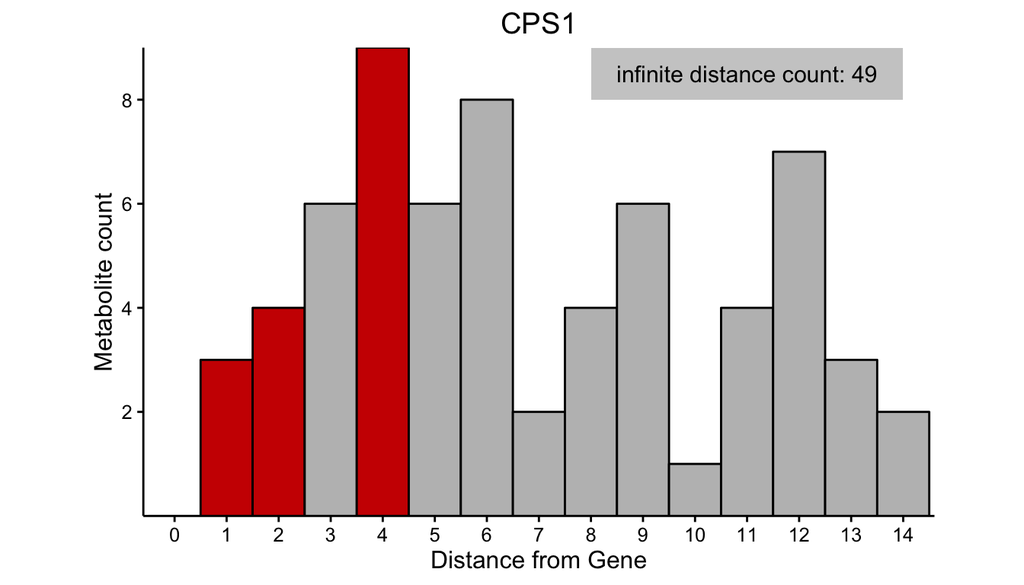

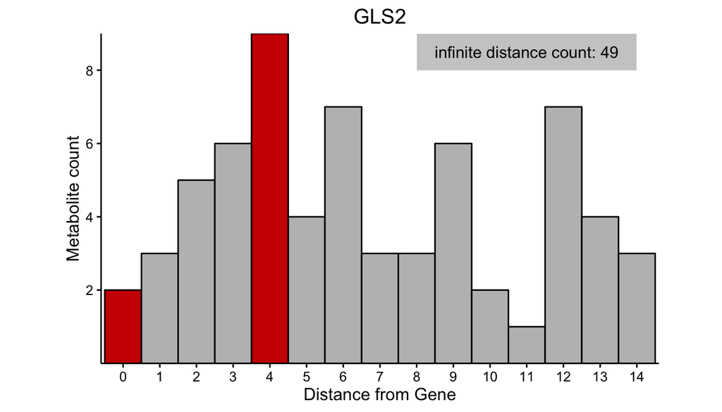

```r
distanceGeneToAllMetabolite(metabolismOverviewMapKEGGId, shinAndAlDF, completeMetaboDF, "hsa:1373")
distanceGeneToAllMetabolite(metabolismOverviewMapKEGGId, shinAndAlDF, completeMetaboDF, "hsa:27165")
```

### heatmapAsso Function

This function calculates the distance between every gene in a associations to every metabolites in an associations. Thus, the purpose of the function is to provide a rapid insight of the difference of the distance between associated or not gene/metabolite pairs. If a distance is Inf, it means both gene and metabolite are on the selected map but no path exist between them.

#### Arguments :

```
pathwayId: is the KEGG Id of the selected map
associatedGeneMetaDF : is a dataFrame with 2 columns. Where each line
                        reprensents an associations with the first column as
                        gene KEGG Ids and the sencond column as metabolite
                        KEGG Ids.
```

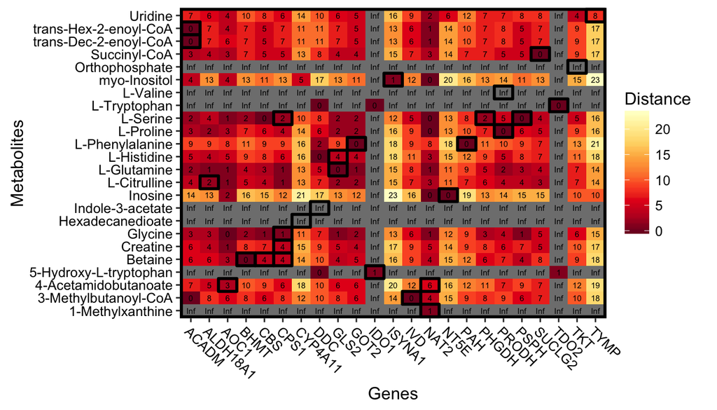

```r
heatmapAsso(metabolismOverviewMapKEGGId, shinAndAlDF)
```

1. Shin, So-Youn et al. “An Atlas of Genetic Influences on Human Blood Metabolites.” Nature genetics 46.6 (2014): 543–550. PMC.